# Binary Classification Model for Seismic Bumps Take 2 Using R

David Lowe

August 31, 2018

Template Credit: Adapted from a template made available by Dr. Jason Brownlee of Machine Learning Mastery. [http://machinelearningmastery.com/]

SUMMARY: The purpose of this project is to construct a prediction model using various machine learning algorithms and to document the end-to-end steps using a template. The Seismic Bumps Data Set is a binary-class classification situation where we are trying to predict one of the two possible outcomes.

INTRODUCTION: Mining activity has always been connected with the occurrence of dangers which are commonly called mining hazards. A special case of such a threat is a seismic hazard which frequently occurs in many underground mines. Seismic hazard is the hardest detectable and predictable of natural hazards, and it is comparable to an earthquake. The complexity of seismic processes and big disproportion between the number of low-energy seismic events and the number of high-energy phenomena causes the statistical techniques to be insufficient to predict seismic hazard. Therefore, it is essential to search for new opportunities for better hazard prediction, also using machine learning methods.

In iteration Take1, we had three algorithms with high accuracy results but with dismal Kappa scores. For this iteration, we will examine the viability of using the ROC scores to rank and choose the models.

CONCLUSION: From the previous Take1 iteration, the baseline performance of the eight algorithms achieved an average accuracy of 93.11%. Three algorithms (Random Forest, Support Vector Machine, and Adaboost) achieved the top three accuracy scores after the first round of modeling. After a series of tuning trials, all three algorithms turned in the identical accuracy result of 93.42%, with an identical Kappa score of 0.0. With an imbalanced dataset we have on-hand, we will need to look for another metric or another approach to evaluate the models.

The ROC metric has given us a more viable way to evaluate the models, other than using the accuracy scores. However, with an imbalanced dataset we have on-hand, we still need to look for another approach to further validate our modeling effort.

Dataset Used: Seismic Bumps Data Set

Dataset ML Model: Binary classification with numerical and categorical attributes

Dataset Reference: https://archive.ics.uci.edu/ml/datasets/seismic-bumps

The project aims to touch on the following areas:

1. Document a predictive modeling problem end-to-end.
2. Explore data cleaning and transformation options
3. Explore non-ensemble and ensemble algorithms for baseline model performance
4. Explore algorithm tuning techniques for improving model performance

Any predictive modeling machine learning project genrally can be broken down into about six major tasks:

1. Prepare Problem
2. Summarize Data
3. Prepare Data
4. Model and Evaluate Algorithms
5. Improve Accuracy or Results
6. Finalize Model and Present Results

## 1. Prepare Problem

### 1.a) Load libraries

```r
library(caret)
```

```r
library(corrplot)
library(ROCR)
library(foreign)
```

### 1.b) Load dataset

```r
startTimeScript <- proc.time()
entireDataset <- read.arff("seismic-bumps.arff")

# Use variable totCol to hold the number of columns in the dataframe
totCol <- ncol(entireDataset)

# Rename the class/target column to a standard label
entireDataset$targetVar="hazardous"
entireDataset$targetVar[entireDataset$class==0] <- "nonhazardous"
entireDataset$class <- NULL
```

```r
# Setting up various variables to control the upcoming data visualization charts
# Set up a variable for the total number of attribute columns (totAttr)
totAttr <- totCol-1

#Which column does the first attribute column begin (1 - First, 2 - second)?
beginAttrCol <- 2
if (beginAttrCol == 1) {
attrColOffset <- 0
} else {
attrColOffset <- 1
}

# Set up the number of row and columns for visualization display. dispRow * dispCol should be >= totAttr
dispCol <- 4
if (totAttr%%dispCol == 0) {
dispRow <- totAttr%/%dispCol
} else {
dispRow <- (totAttr%/%dispCol) + 1
}
cat("Will attempt to create graphics grid (col x row): ", dispCol, ' by ', dispRow)
```

```
## Will attempt to create graphics grid (col x row):  4  by  5
```

## 2. Summarize Data

To gain a better understanding of the data that we have on-hand, we will leverage a number of descriptive statistics and data visualization techniques. The plan is to use the results to consider new questions, review assumptions, and validate hypotheses that we can investigate later with specialized models.

### 2.a) Descriptive statistics

#### 2.a.i) Peek at the data itself.

```r
head(entireDataset)
```

```
##   seismic seismoacoustic shift genergy gpuls gdenergy gdpuls ghazard
## 1       a              a     N   15180    48      -72    -72       a
## 2       a              a     N   14720    33      -70    -79       a
## 3       a              a     N    8050    30      -81    -78       a
## 4       a              a     N   28820   171      -23     40       a
## 5       a              a     N   12640    57      -63    -52       a
## 6       a              a     W   63760   195      -73    -65       a
##   nbumps nbumps2 nbumps3 nbumps4 nbumps5 nbumps6 nbumps7 nbumps89 energy
## 1      0       0       0       0       0       0       0        0      0
## 2      1       0       1       0       0       0       0        0   2000
## 3      0       0       0       0       0       0       0        0      0
## 4      1       0       1       0       0       0       0        0   3000
## 5      0       0       0       0       0       0       0        0      0
## 6      0       0       0       0       0       0       0        0      0
##   maxenergy    targetVar
## 1         0 nonhazardous
## 2      2000 nonhazardous
## 3         0 nonhazardous
## 4      3000 nonhazardous
## 5         0 nonhazardous
## 6         0 nonhazardous
```

#### 2.a.ii) Dimensions of the dataset.

```r
dim(entireDataset)
```

```
## [1] 2584   19
```

#### 2.a.iii) Types of the attributes.

```r
sapply(entireDataset, class)
```

```
##        seismic seismoacoustic          shift        genergy          gpuls
##       "factor"       "factor"       "factor"      "numeric"      "numeric"
##       gdenergy         gdpuls        ghazard         nbumps        nbumps2
##      "numeric"      "numeric"       "factor"      "numeric"      "numeric"
##        nbumps3        nbumps4        nbumps5        nbumps6        nbumps7
##      "numeric"      "numeric"      "numeric"      "numeric"      "numeric"
##       nbumps89         energy      maxenergy      targetVar
##      "numeric"      "numeric"      "numeric"    "character"
```

#### 2.a.iv) Statistical summary of all attributes.

```r
summary(entireDataset)
```

```
##  seismic  seismoacoustic shift       genergy            gpuls
##  a:1682   a:1580         N: 921   Min.   :    100   Min.   :   2.0
##  b: 902   b: 956         W:1663   1st Qu.:  11660   1st Qu.: 190.0
##           c:  48                  Median :  25485   Median : 379.0
##                                   Mean   :  90243   Mean   : 538.6
##                                   3rd Qu.:  52833   3rd Qu.: 669.0
##                                   Max.   :2595650   Max.   :4518.0
##     gdenergy           gdpuls        ghazard      nbumps
##  Min.   : -96.00   Min.   :-96.000   a:2342   Min.   :0.0000
##  1st Qu.: -37.00   1st Qu.:-36.000   b: 212   1st Qu.:0.0000
##  Median :  -6.00   Median : -6.000   c:  30   Median :0.0000
##  Mean   :  12.38   Mean   :  4.509            Mean   :0.8595
##  3rd Qu.:  38.00   3rd Qu.: 30.250            3rd Qu.:1.0000
##  Max.   :1245.00   Max.   :838.000            Max.   :9.0000
##     nbumps2          nbumps3          nbumps4           nbumps5
##  Min.   :0.0000   Min.   :0.0000   Min.   :0.00000   Min.   :0.000000
##  1st Qu.:0.0000   1st Qu.:0.0000   1st Qu.:0.00000   1st Qu.:0.000000
##  Median :0.0000   Median :0.0000   Median :0.00000   Median :0.000000
##  Mean   :0.3936   Mean   :0.3928   Mean   :0.06772   Mean   :0.004644
##  3rd Qu.:1.0000   3rd Qu.:1.0000   3rd Qu.:0.00000   3rd Qu.:0.000000
##  Max.   :8.0000   Max.   :7.0000   Max.   :3.00000   Max.   :1.000000
##     nbumps6     nbumps7     nbumps89     energy         maxenergy
##  Min.   :0   Min.   :0   Min.   :0   Min.   :     0   Min.   :     0
##  1st Qu.:0   1st Qu.:0   1st Qu.:0   1st Qu.:     0   1st Qu.:     0
##  Median :0   Median :0   Median :0   Median :     0   Median :     0
##  Mean   :0   Mean   :0   Mean   :0   Mean   :  4975   Mean   :  4279
##  3rd Qu.:0   3rd Qu.:0   3rd Qu.:0   3rd Qu.:  2600   3rd Qu.:  2000
##  Max.   :0   Max.   :0   Max.   :0   Max.   :402000   Max.   :400000
##   targetVar
##  Length:2584
##  Class :character
##  Mode  :character
##
##
##
```

#### 2.a.v) Summarize the levels of the class attribute.

```r
entireDataset_x <- entireDataset[,1:(totCol-1)]
entireDataset_y <- entireDataset[,totCol]
cbind(freq=table(entireDataset_y), percentage=prop.table(table(entireDataset_y))*100)
```

```
##              freq percentage
## hazardous     170   6.578947
## nonhazardous 2414  93.421053
```

#### 2.a.vi) Count missing values.

```r
sapply(entireDataset, function(x) sum(is.na(x)))
```

```
##        seismic seismoacoustic          shift        genergy          gpuls
##              0              0              0              0              0
##       gdenergy         gdpuls        ghazard         nbumps        nbumps2
##              0              0              0              0              0
##        nbumps3        nbumps4        nbumps5        nbumps6        nbumps7
##              0              0              0              0              0
##       nbumps89         energy      maxenergy      targetVar
##              0              0              0              0
```

### 2.b) Data visualizations

#### 2.b.i) Univariate plots to better understand each attribute.

```r
# Boxplots for each attribute
#par(mfrow=c(dispRow,dispCol))
#for(i in beginAttrCol:(totAttr+attrColOffset)) {
#   boxplot(entireDataset[,i], main=names(entireDataset)[i])
#}
```

```r
# Histograms each attribute
#par(mfrow=c(dispRow,dispCol))
#for(i in beginAttrCol:(totAttr+attrColOffset)) {
#   hist(entireDataset[,i], main=names(entireDataset)[i])
#}
```

```r
# Density plot for each attribute
#par(mfrow=c(dispRow,dispCol))
#for(i in beginAttrCol:(totAttr+attrColOffset)) {
#   plot(density(entireDataset[,i]), main=names(entireDataset)[i])
#}
```

#### 2.b.ii) Multivariate plots to better understand the relationships between attributes

```r
# Scatterplot matrix colored by class
#pairs(targetVar~., data=entireDataset, col=entireDataset$targetVar)
```

```r
# Box and whisker plots for each attribute by class
#scales <- list(x=list(relation="free"), y=list(relation="free"))
#featurePlot(x=entireDataset_x, y=entireDataset_y, plot="box", scales=scales)
```

```r
# Density plots for each attribute by class value
#featurePlot(x=entireDataset_x, y=entireDataset_y, plot="density", scales=scales)
```

```r
# Correlation plot
#correlations <- cor(entireDataset_x)
#corrplot(correlations, method="circle")
```

## 3. Prepare Data

Some dataset may require additional preparation activities that will best exposes the structure of the problem and the relationships between the input attributes and the output variable. Some data-prep tasks might include:

- Cleaning data by removing duplicates, marking missing values and even imputing missing values.
- Feature selection where redundant features may be removed.
- Data transforms where attributes are scaled or redistributed in order to best expose the structure of the problem later to learning algorithms.

### 3.a) Data Cleaning

```r
# Not applicable for this iteration of the project.

# Mark missing values
#invalid <- 0
#entireDataset$some_col[entireDataset$some_col==invalid] <- NA

# Impute missing values
#entireDataset$some_col <- with(entireDataset, impute(some_col, mean))
```

### 3.b) Feature Selection

```r
# Not applicable for this iteration of the project.
```

### 3.c) Data Transforms

```r
# Not applicable for this iteration of the project.
```

### 3.d) Split-out training and validation datasets

We create a training dataset (variable name “training”) and a validation dataset (variable name “validation”).

```r
seedNum <- 888
set.seed(seedNum)

# Create a list of the rows in the original dataset we can use for training
training_index <- createDataPartition(entireDataset$targetVar, p=0.70, list=FALSE)

# Use 70% of data to training and testing the models
training <- entireDataset[training_index,]

# Select the remaining 30% of the data for validation
validation <- entireDataset[-training_index,]
```

```r
proc.time()-startTimeScript
```

```
##    user  system elapsed
##    0.64    0.20    0.85
```

## 4. Model and Evaluate Algorithms

After the data-prep, we next work on finding a workable model by evaluating a subset of machine learning algorithms that are good at exploiting the structure of the training. The typical evaluation tasks include:

- Defining test options such as cross validation and the evaluation metric to use.
- Spot checking a suite of linear and nonlinear machine learning algorithms.
- Comparing the estimated accuracy of algorithms.

For this project, we will evaluate one linear, three non-linear, and four ensemble algorithms:

Linear Algorithm: Logistic Regression

Non-Linear Algorithms: Decision Trees (CART), k-Nearest Neighbors, and Support Vector Machine

Ensemble Algorithms: Bagged CART, Random Forest, Adaboost, and Stochastic Gradient Boosting

The random number seed is reset before each run to ensure that the evaluation of each algorithm is performed using the same data splits. It ensures the results are directly comparable.

### 4.a) Set test options and evaluation metric

```r
# Run algorithms using 10-fold cross validation
control <- trainControl(method="repeatedcv", number=10, repeats=3, classProbs=TRUE, summaryFunction = twoClassSummary)
metricTarget <- "ROC"
```

### 4.b) Generate models using linear algorithms

```r
# Logistic Regression (Classification)
startTimeModule <- proc.time()
set.seed(seedNum)
fit.glm <- train(targetVar~., data=training, method="glm", metric=metricTarget, trControl=control)
```

[output not shown]

[output cut: 34 more lines]

[output not shown]

[output not shown]

```r
proc.time()-startTimeModule
```

```
##    user  system elapsed
##    1.99    0.07    2.05
```

### 4.c) Generate models using nonlinear algorithms

```r
# Decision Tree - CART (Regression/Classification)
startTimeModule <- proc.time()
set.seed(seedNum)
fit.cart <- train(targetVar~., data=training, method="rpart", metric=metricTarget, trControl=control)
proc.time()-startTimeModule
```

```
##    user  system elapsed
##    1.66    0.00    1.73
```

```r
# k-Nearest Neighbors (Regression/Classification)
startTimeModule <- proc.time()
set.seed(seedNum)
fit.knn <- train(targetVar~., data=training, method="knn", metric=metricTarget, trControl=control)
proc.time()-startTimeModule
```

```
##    user  system elapsed
##    2.47    0.00    2.50
```

```r
# Support Vector Machine (Regression/Classification)
startTimeModule <- proc.time()
set.seed(seedNum)
fit.svm <- train(targetVar~., data=training, method="svmRadial", metric=metricTarget, trControl=control)
```

[output not shown]

[output cut: 128 more lines]

[output not shown]

```r
proc.time()-startTimeModule
```

```
##    user  system elapsed
##   32.22    0.69   33.47
```

### 4.d) Generate models using ensemble algorithms

In this section, we will explore the use and tuning of ensemble algorithms to see whether we can improve the results.

```r
# Bagged CART (Regression/Classification)
startTimeModule <- proc.time()
set.seed(seedNum)
fit.bagcart <- train(targetVar~., data=training, method="treebag", metric=metricTarget, trControl=control)
proc.time()-startTimeModule
```

```
##    user  system elapsed
##   15.39    0.05   16.00
```

```r
# Random Forest (Regression/Classification)
startTimeModule <- proc.time()
set.seed(seedNum)
fit.rf <- train(targetVar~., data=training, method="rf", metric=metricTarget, trControl=control)
proc.time()-startTimeModule
```

```
##    user  system elapsed
##  113.12    2.35  118.25
```

```r
# AdaBoost (Classification)
startTimeModule <- proc.time()
set.seed(seedNum)
fit.ada <- train(targetVar~., data=training, method="ada", metric=metricTarget, trControl=control)
proc.time()-startTimeModule
```

```
##    user  system elapsed
##  340.87    0.05  341.48
```

```r
# Stochastic Gradient Boosting (Regression/Classification)
startTimeModule <- proc.time()
set.seed(seedNum)
fit.gbm <- train(targetVar~., data=training, method="gbm", metric=metricTarget, trControl=control, verbose=F)
proc.time()-startTimeModule
```

```
##    user  system elapsed
##   17.52    0.02   17.58
```

### 4.e) Compare baseline algorithms

```r
results <- resamples(list(LR=fit.glm, CART=fit.cart, kNN=fit.knn, SVM=fit.svm, BagCART=fit.bagcart, RF=fit.rf, AdaBoost=fit.ada, GBM=fit.gbm))
summary(results)
```

```
##
## Call:
## summary.resamples(object = results)
##
## Models: LR, CART, kNN, SVM, BagCART, RF, AdaBoost, GBM
## Number of resamples: 30
##
## ROC
##               Min.   1st Qu.    Median      Mean   3rd Qu.      Max. NA's
## LR       0.5522682 0.7077170 0.7391519 0.7387619 0.7862426 0.8499193    0
## CART     0.5170118 0.6823841 0.7258383 0.7270157 0.7750583 0.8897929    0
## kNN      0.5332840 0.6137204 0.6910750 0.6702424 0.7178254 0.7716963    0
## SVM      0.4127219 0.5332168 0.6062623 0.6152950 0.6838018 0.8333333    0
## BagCART  0.6050296 0.6560651 0.6903353 0.6977564 0.7416958 0.7882150    0
## RF       0.6309172 0.6878698 0.7749014 0.7582183 0.8118836 0.8957101    0
## AdaBoost 0.6656805 0.7647313 0.7822978 0.7839049 0.8256287 0.8915187    0
## GBM      0.6511341 0.7143738 0.7672584 0.7682692 0.8081854 0.9060651    0
##
## Sens
##          Min.    1st Qu.     Median        Mean    3rd Qu.       Max. NA's
## LR          0 0.00000000 0.00000000 0.039141414 0.08333333 0.16666667    0
## CART        0 0.08333333 0.16666667 0.166161616 0.23295455 0.54545455    0
## kNN         0 0.00000000 0.00000000 0.008585859 0.00000000 0.09090909    0
## SVM         0 0.00000000 0.00000000 0.002777778 0.00000000 0.08333333    0
## BagCART     0 0.00000000 0.08333333 0.067424242 0.08333333 0.27272727    0
## RF          0 0.00000000 0.00000000 0.000000000 0.00000000 0.00000000    0
## AdaBoost    0 0.00000000 0.00000000 0.028282828 0.06250000 0.16666667    0
## GBM         0 0.00000000 0.00000000 0.022474747 0.06250000 0.09090909    0
##
## Spec
##               Min.   1st Qu.    Median      Mean   3rd Qu. Max. NA's
## LR       0.9881657 0.9896450 0.9940828 0.9950690 1.0000000    1    0
## CART     0.9467456 0.9644970 0.9763314 0.9761341 0.9822485    1    0
## kNN      0.9822485 0.9940828 0.9940828 0.9952663 1.0000000    1    0
## SVM      0.9763314 0.9940828 1.0000000 0.9968442 1.0000000    1    0
## BagCART  0.9704142 0.9822485 0.9881657 0.9881657 0.9940828    1    0
## RF       0.9940828 1.0000000 1.0000000 0.9998028 1.0000000    1    0
## AdaBoost 0.9940828 0.9940828 1.0000000 0.9980276 1.0000000    1    0
## GBM      0.9881657 0.9940828 1.0000000 0.9974359 1.0000000    1    0
```

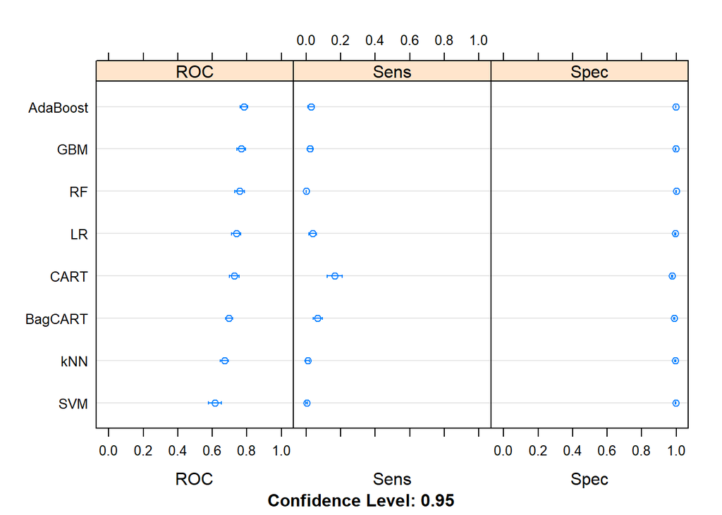

```r
dotplot(results)
```

## 5. Improve Accuracy or Results

After we achieve a short list of machine learning algorithms with good level of accuracy, we can leverage ways to improve the accuracy of the models.

Using the three best-perfoming algorithms from the previous section, we will Search for a combination of parameters for each algorithm that yields the best results.

### 5.a) Algorithm Tuning

Finally, we will tune the best-performing algorithms from each group further and see whether we can get more accuracy out of them.

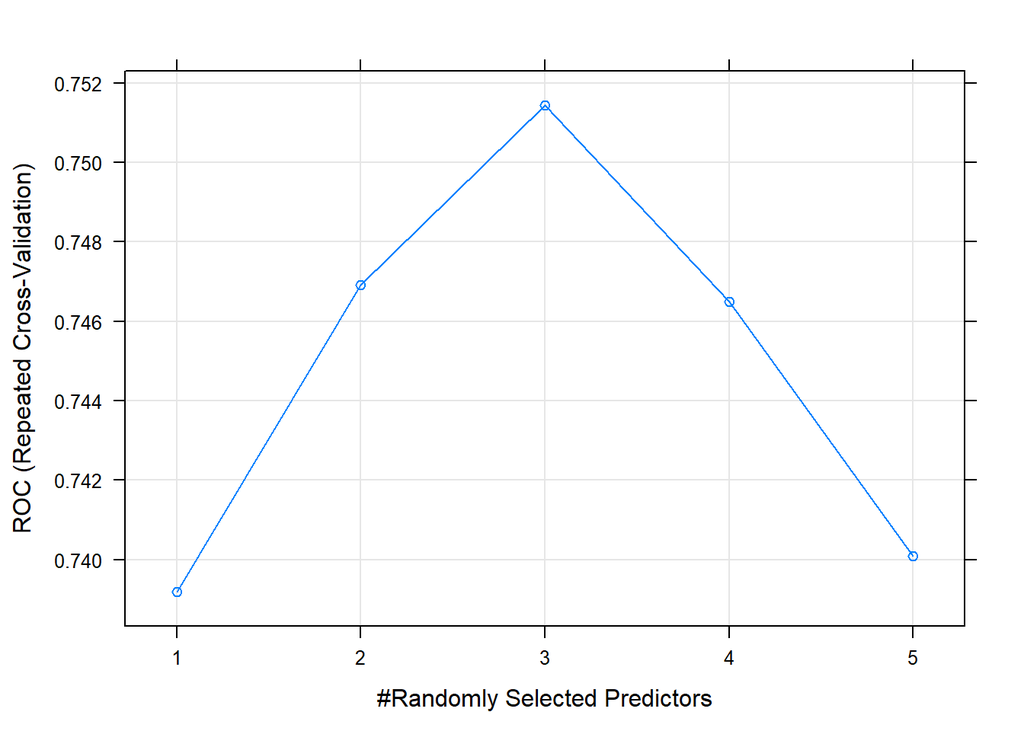

```r
# Tuning algorithm #1 - Random Forest
startTimeModule <- proc.time()
set.seed(seedNum)
grid <- expand.grid(mtry = c(1:5))
fit.final1 <- train(targetVar~., data=training, method="rf", metric=metricTarget, tuneGrid=grid, trControl=control)
plot(fit.final1)
```

```r
print(fit.final1)
```

```
## Random Forest
##
## 1809 samples
##   18 predictor
##    2 classes: 'hazardous', 'nonhazardous'
##
## No pre-processing
## Resampling: Cross-Validated (10 fold, repeated 3 times)
## Summary of sample sizes: 1628, 1629, 1628, 1628, 1628, 1628, ...
## Resampling results across tuning parameters:
##
##   mtry  ROC        Sens        Spec
##   1     0.7391855  0.00000000  1.0000000
##   2     0.7469077  0.00000000  0.9996055
##   3     0.7514442  0.01161616  0.9984221
##   4     0.7464953  0.03939394  0.9954635
##   5     0.7400962  0.04242424  0.9944773
##
## ROC was used to select the optimal model using the largest value.
## The final value used for the model was mtry = 3.
```

```r
proc.time()-startTimeModule
```

```
##    user  system elapsed
##  129.30    2.92  132.36
```

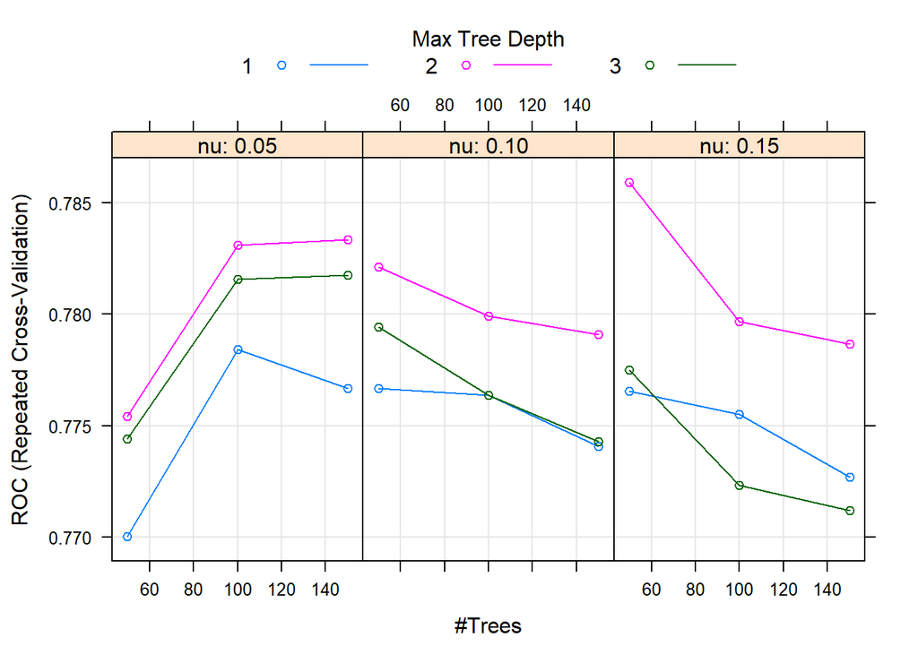

```r
# Tuning algorithm #2 - Adaboost
startTimeModule <- proc.time()
set.seed(seedNum)
grid <- expand.grid(iter=c(50, 100, 150), maxdepth=c(1, 2, 3), nu=c(0.05, 0.1, 0.15))
fit.final2 <- train(targetVar~., data=training, method="ada", metric=metricTarget, tuneGrid=grid, trControl=control, verbose=F)
plot(fit.final2)
```

```r
print(fit.final2)
```

```
## Boosted Classification Trees
##
## 1809 samples
##   18 predictor
##    2 classes: 'hazardous', 'nonhazardous'
##
## No pre-processing
## Resampling: Cross-Validated (10 fold, repeated 3 times)
## Summary of sample sizes: 1628, 1629, 1628, 1628, 1628, 1628, ...
## Resampling results across tuning parameters:
##
##   nu    maxdepth  iter  ROC        Sens         Spec
##   0.05  1          50   0.7700391  0.000000000  1.0000000
##   0.05  1         100   0.7784166  0.000000000  1.0000000
##   0.05  1         150   0.7766601  0.000000000  1.0000000
##   0.05  2          50   0.7754244  0.000000000  1.0000000
##   0.05  2         100   0.7830868  0.005808081  1.0000000
##   0.05  2         150   0.7833513  0.005808081  0.9996055
##   0.05  3          50   0.7744158  0.011363636  0.9992110
##   0.05  3         100   0.7815574  0.022979798  0.9992110
##   0.05  3         150   0.7817480  0.028787879  0.9990138
##   0.10  1          50   0.7766631  0.000000000  1.0000000
##   0.10  1         100   0.7763598  0.000000000  1.0000000
##   0.10  1         150   0.7740878  0.000000000  1.0000000
##   0.10  2          50   0.7821066  0.002777778  0.9994083
##   0.10  2         100   0.7799302  0.008585859  0.9994083
##   0.10  2         150   0.7790807  0.011363636  0.9994083
##   0.10  3          50   0.7794319  0.017171717  0.9980276
##   0.10  3         100   0.7763784  0.028282828  0.9968442
##   0.10  3         150   0.7742947  0.036868687  0.9968442
##   0.15  1          50   0.7765615  0.000000000  1.0000000
##   0.15  1         100   0.7755125  0.000000000  1.0000000
##   0.15  1         150   0.7726951  0.000000000  1.0000000
##   0.15  2          50   0.7859064  0.008838384  0.9988166
##   0.15  2         100   0.7796755  0.014393939  0.9988166
##   0.15  2         150   0.7786654  0.019949495  0.9984221
##   0.15  3          50   0.7774916  0.036616162  0.9978304
##   0.15  3         100   0.7723425  0.044949495  0.9966469
##   0.15  3         150   0.7712047  0.039393939  0.9968442
##
## ROC was used to select the optimal model using the largest value.
## The final values used for the model were iter = 50, maxdepth = 2 and nu
##  = 0.15.
```

```r
proc.time()-startTimeModule
```

```
##    user  system elapsed
## 1129.76    0.86 1163.63
```

```r
# Tuning algorithm #3 - Stochastic Gradient Boosting
startTimeModule <- proc.time()
set.seed(seedNum)
grid <- expand.grid(.n.trees=c(50, 100, 200), .shrinkage=c(0.01, 0.05, 0.1), .interaction.depth=c(1, 2, 3), .n.minobsinnode=c(3, 5, 7))
fit.final3 <- train(targetVar~., data=training, method="gbm", metric=metricTarget, tuneGrid=grid, trControl=control, verbose=F)
```

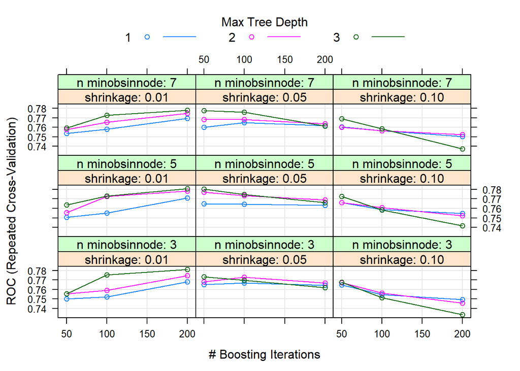

```r
plot(fit.final3)
```

```r
print(fit.final3)
```

```
## Stochastic Gradient Boosting
##
## 1809 samples
##   18 predictor
##    2 classes: 'hazardous', 'nonhazardous'
##
## No pre-processing
## Resampling: Cross-Validated (10 fold, repeated 3 times)
## Summary of sample sizes: 1628, 1629, 1628, 1628, 1628, 1628, ...
## Resampling results across tuning parameters:
##
##   shrinkage  interaction.depth  n.minobsinnode  n.trees  ROC
##   0.01       1                  3                50      0.7502630
##   0.01       1                  3               100      0.7520635
##   0.01       1                  3               200      0.7679652
##   0.01       1                  5                50      0.7507546
##   0.01       1                  5               100      0.7550632
##   0.01       1                  5               200      0.7707945
##   0.01       1                  7                50      0.7535593
##   0.01       1                  7               100      0.7581757
##   0.01       1                  7               200      0.7692846
##   0.01       2                  3                50      0.7553867
##   0.01       2                  3               100      0.7590513
##   0.01       2                  3               200      0.7746227
##   0.01       2                  5                50      0.7555802
##   0.01       2                  5               100      0.7728281
##   0.01       2                  5               200      0.7782813
##   0.01       2                  7                50      0.7576759
##   0.01       2                  7               100      0.7651665
##   0.01       2                  7               200      0.7745958
##   0.01       3                  3                50      0.7554009
##   0.01       3                  3               100      0.7752824
##   0.01       3                  3               200      0.7810345
##   0.01       3                  5                50      0.7634600
##   0.01       3                  5               100      0.7728961
##   0.01       3                  5               200      0.7806340
##   0.01       3                  7                50      0.7590887
##   0.01       3                  7               100      0.7728274
##   0.01       3                  7               200      0.7779952
##   0.05       1                  3                50      0.7651358
```

[output cut: 124 more lines]

```
##   0.061616162  0.9932939
##   0.092676768  0.9885602
##   0.090404040  0.9925049
##   0.109848485  0.9897436
##   0.106818182  0.9856016
##   0.084343434  0.9940828
##   0.089898990  0.9921105
##   0.107070707  0.9885602
##   0.076010101  0.9930966
##   0.101010101  0.9913215
##   0.104292929  0.9873767
##
## ROC was used to select the optimal model using the largest value.
## The final values used for the model were n.trees = 200,
##  interaction.depth = 3, shrinkage = 0.01 and n.minobsinnode = 3.
```

```r
proc.time()-startTimeModule
```

```
##    user  system elapsed
##  242.87    0.55  262.25
```

### 5.d) Compare Algorithms After Tuning

```r
results <- resamples(list(RF=fit.final1, ADA=fit.final2, GBM=fit.final3))
summary(results)
```

```
##
## Call:
## summary.resamples(object = results)
##
## Models: RF, ADA, GBM
## Number of resamples: 30
##
## ROC
##          Min.   1st Qu.    Median      Mean   3rd Qu.      Max. NA's
## RF  0.6235207 0.6953279 0.7470414 0.7514442 0.8108302 0.8976824    0
## ADA 0.6856509 0.7570266 0.7809082 0.7859064 0.8269231 0.8925049    0
## GBM 0.6711045 0.7279956 0.7768738 0.7810345 0.8258752 0.9294872    0
##
## Sens
##     Min. 1st Qu. Median        Mean 3rd Qu.       Max. NA's
## RF     0       0      0 0.011616162       0 0.09090909    0
## ADA    0       0      0 0.008838384       0 0.18181818    0
## GBM    0       0      0 0.017171717       0 0.09090909    0
##
## Spec
##          Min.   1st Qu. Median      Mean 3rd Qu. Max. NA's
## RF  0.9940828 0.9955621      1 0.9984221       1    1    0
## ADA 0.9940828 1.0000000      1 0.9988166       1    1    0
## GBM 0.9940828 0.9955621      1 0.9984221       1    1    0
```

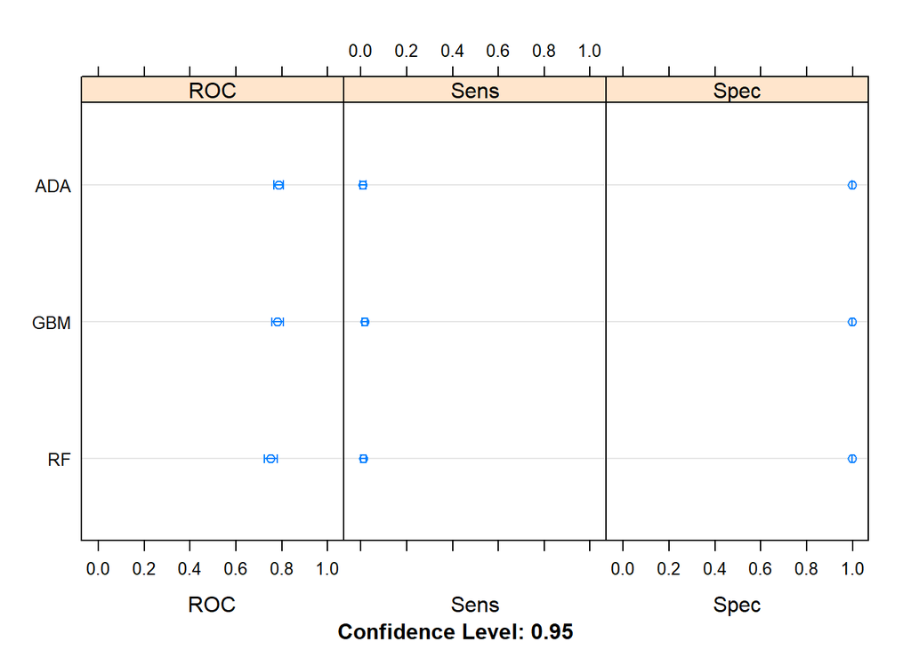

```r
dotplot(results)
```

## 6. Finalize Model and Present Results

Once we have narrow down to a model that we believe can make accurate predictions on unseen data, we are ready to finalize it. Finalizing a model may involve sub-tasks such as:

- Using an optimal model tuned to make predictions on unseen data.
- Creating a standalone model using the tuned parameters
- Saving an optimal model to file for later use.

### 6.a) Predictions on validation dataset

```r
#predictions <- predict(fit.final2, newdata=validation)
#confusionMatrix(predictions, validation$targetVar)

#pred <- prediction(as.numeric(predictions), as.numeric(validation$targetVar))
#perf <- performance(pred, measure = "tpr", x.measure = "fpr")
#plot(perf, colorize=TRUE)
#auc <- performance(pred, measure = "auc")
#auc <- auc@y.values[[1]]
#auc
```

### 6.b) Create standalone model on entire training dataset

```r
startTimeModule <- proc.time()
set.seed(seedNum)
#grid <- expand.grid(sigma = 0.015, C = 1)
#finalModel <- train(targetVar~., data=entireDataset, method="svmRadial", metric=metricTarget, tuneGrid=grid, trControl=control)
#print(finalModel)
proc.time()-startTimeModule
```

```
##    user  system elapsed
##       0       0       0
```

### 6.c) Save model for later use

```r
#saveRDS(finalModel, "./finalModel_BinaryClass.rds")
```

```r
proc.time()-startTimeScript
```

```
##    user  system elapsed
## 2216.98    8.17 2283.06
```